# Data Exploration Project

Kyle Bailey

Research Question:

The College Scorecard was released at the start of September 2015. Among colleges that predominantly grant bachelor’s degrees, did the release of the Scorecard shift student interest to high-earnings colleges relative to low-earnings ones (as proxied by Google searches for keywords associated with those colleges)?

Data cleaning:

```r
#load libraries

library(purrr)
library(tidyverse)
library(car)
library(fmtr)
library(jtools)
library(dplyr)
library(readr)
```

```r
#joining id_name_link to trends

id_name_link_trends <- left_join(x = id_name_link, y = trends, by = "schname")

#joining id_name_link & trends to scorecard

data <- left_join(x = id_name_link_trends, y = scorecard, by = c("unitid" = "UNITID"))
```

Set up:

```r
#group dates by month or week

month_week <- data %>%
  group_by(monthorweek) %>%
  summarize(n = n())

#remove dates that are marked as 'NA'

month_week_clean <- na.omit(month_week, c("monthorweek"))

#filtering out dates after September 2015

pre_scorecard <- month_week_clean$monthorweek[1:128]
pre_scorecard <- as.data.frame(pre_scorecard)

#creating a dummy variable for dates before September 2015

data$scorecard_implimented <- ifelse(data$monthorweek %in% pre_scorecard$pre_scorecard, 0, 1)

data <- data %>%
  relocate(scorecard_implimented, .after = monthorweek)
```

```r
#group schools by income & remove schools with no earnings data

earnings <- data %>%
  group_by(unitid, schname) %>%
  summarize(mean(as.numeric(md_earn_wne_p10.REPORTED.EARNINGS))) %>%
  na.omit(earnings, c("md_earn_wne_p10.REPORTED.EARNINGS"))

earnings <- rename(earnings, AverageEarnings = 'mean(as.numeric(md_earn_wne_p10.REPORTED.EARNINGS))')

#getting the mean and standard deviation of all the mean earnings for schools

mean_earnings <- mean(earnings$AverageEarnings)
stdev_earnings <- sd(earnings$AverageEarnings)

mean_earnings
```

```
## [1] 42267.62
```

```r
stdev_earnings
```

```
## [1] 11770.71
```

```r
data <- data %>%
  relocate(md_earn_wne_p10.REPORTED.EARNINGS, .after = opeid6)

data <- rename(data, reported_earnings = md_earn_wne_p10.REPORTED.EARNINGS)
```

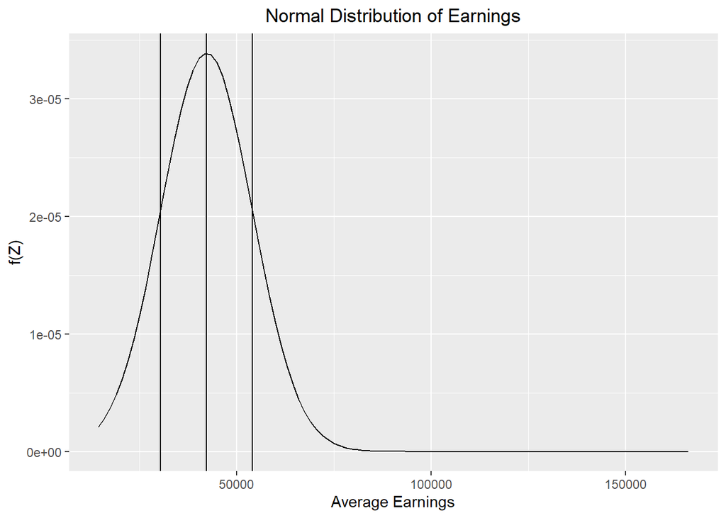

```r
#defining high & low earnings

dist <- ggplot(data = earnings, aes(x = AverageEarnings)) +
  stat_function(fun = dnorm, args = list(mean = mean(earnings$AverageEarnings), sd = sd(earnings$AverageEarnings))) +
  geom_vline(xintercept = mean(earnings$AverageEarnings)) +
  geom_vline(xintercept = mean(earnings$AverageEarnings)+sd(earnings$AverageEarnings)) +
  geom_vline(xintercept = mean(earnings$AverageEarnings)-sd(earnings$AverageEarnings)) +
  labs(title = "Normal Distribution of Earnings", x = "Average Earnings", y = "f(Z)") +
  theme(plot.title = element_text(hjust = 0.5))

dist
```

```r
#high earnings will be one standard deviation above the mean and low earnings will be one standard deviation below the mean

mean_earnings + stdev_earnings
```

```
## [1] 54038.32
```

```r
mean_earnings - stdev_earnings
```

```
## [1] 30496.91
```

```r
#creating binary variables for high/low earners

data$high_earners <- ifelse(data$reported_earnings >= 54038.32, "1", "0")
data$low_earners <- ifelse(data$reported_earnings <= 30496.91, "1", "0")

data <- data %>%
  relocate(high_earners, .after = reported_earnings) %>%
  relocate(low_earners, .after = high_earners)
```

```r
#standardizing the Index

data <- data %>%
  group_by(unitid, schname) %>%
  filter(index != "NA") %>%
  mutate(standardized_index = scale(index, center = TRUE, scale = TRUE))

data <- data %>%
  relocate(standardized_index, .after = index)

summary(data$standardized_index)
```

```
##        V1
##  Min.   :-4.7414
##  1st Qu.:-0.7295
##  Median :-0.0246
##  Mean   : 0.0000
##  3rd Qu.: 0.6952
##  Max.   :10.4148
```

Graphical Analysis:

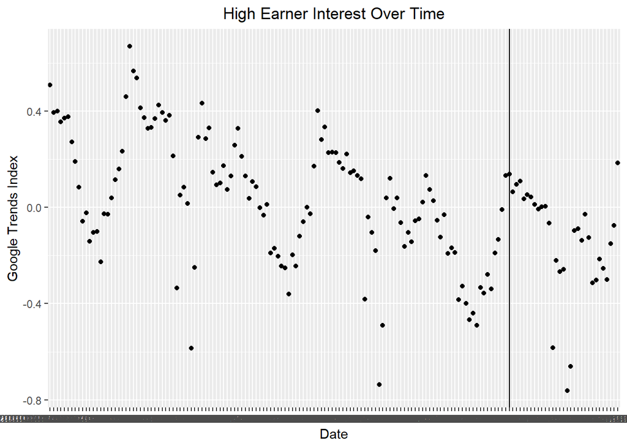

```r
#graphing Google Trends indices over time for high earners

weeklysearcheshigh <- data %>%
  group_by(monthorweek, high_earners) %>%
  summarize(mean(standardized_index)) %>%
  filter(high_earners == 1)
colnames(weeklysearcheshigh)[3] = "index"

g1 <- ggplot(data = weeklysearcheshigh, aes(x = monthorweek, y = index)) +
  geom_point() +
  geom_vline(xintercept = "2015-08-30 - 2015-09-05") +
  labs(title = "High Earner Interest Over Time", x = "Date", y = "Google Trends Index") +
  theme(plot.title = element_text(hjust = 0.5))

g1
```

[figure not shown]

```r
#graphing Google Trends indices over time for low earners

weeklysearcheslow <- data %>%
  group_by(monthorweek, low_earners) %>%
  summarize(mean(standardized_index)) %>%
  filter(low_earners == 1)
colnames(weeklysearcheslow)[3] = "index"

g2 <- ggplot(data = weeklysearcheslow, aes(x = monthorweek, y = index)) +
  geom_point() +
  geom_vline(xintercept = "2015-08-30 - 2015-09-05") +
  labs(title = "Low Earner Interest Over Time", x = "Date", y = "Google Trends Index") +
  theme(plot.title = element_text(hjust = 0.5))

g2
```

```r
#testing various regressions

regression1 <- lm(standardized_index ~ scorecard_implimented, data = data)
regression2 <- lm(standardized_index ~ scorecard_implimented*high_earners, data = data)
regression3 <- lm(standardized_index ~ scorecard_implimented*low_earners, data = data)

export_summs(regression1, regression2, regression3)
```

|  | Model 1 | Model 2 | Model 3 |
| --- | --- | --- | --- |
| (Intercept) | 0.03 *** | 0.03 *** | 0.03 *** |
|  | (0.00) | (0.00) | (0.00) |
| scorecard_implimented | -0.18 *** | -0.18 *** | -0.18 *** |
|  | (0.00) | (0.00) | (0.00) |
| high_earners1 |  | 0.00 |  |
|  |  | (0.00) |  |
| scorecard_implimented:high_earners1 |  | -0.01 |  |
|  |  | (0.01) |  |
| low_earners1 |  |  | -0.00 |
|  |  |  | (0.00) |
| scorecard_implimented:low_earners1 |  |  | 0.00 |
|  |  |  | (0.01) |
| N | 1014836 | 1014836 | 1014836 |
| R2 | 0.00 | 0.00 | 0.00 |
| *** p < 0.001; ** p < 0.01; * p < 0.05. |  |  |  |

Write-up:

We used Google trends data for colleges combined with Scorecard data that gives us a lot of information about students that have graduated from these colleges and universities. Scorecard’s implementation in September 2015 is what we are trying to examine in its effects on whether or not students shifted their interest to high-earning colleges relative to low-earning colleges.

To further pursue our research question, I needed to remove all universities that shared the same name so we could have consistent data that was not affected by duplicates and selected only colleges that predominantly offered bachelor’s degrees. Additionally, I created a binary variable for before and after the implementation of Scorecard in September 2015 so we can analyze that later on.

After assembling and cleaning the data, I did some analysis on graduate earnings to determine the cutoffs for high or low earning colleges. To do this I took the average income for each college and set the range as plus or minus one standard deviation from the mean. This range encapsulated the mean income of $42,267.61 and a standard deviation of $11,770.71. Thus, our low earners were those who made $30,496.91 and our high earners were those who made $54,038.32. Given that each value of a Google Trends index is unique to the institution that it is describing, I standardized the indices by subtracting each the mean of the index values from the index and dividing that by the standard deviation of the indices. This gave us a level playing field to analyze the Trends data freely across all institutions.

I wanted to get a clear picture of how interest in colleges with higher and lower earning graduates changed before and after Scorecard was implemented so I graphed both over the period of time supplied which was 2013 to 2016. Looking at these graphs it wasn’t clear to me whether or not Scorecard had any impact on interest as the overall trends seemed to remain constant, peaking occasionally from what I assumed to be admissions and recruiting periods but remaining fairly constant before and after the September 2015 drop date of Scorecard (seen as the vertical line on both graphs). In fact, there was a slight downward trend in the graphs for both groups.

Ultimately, there is little evidence here to conclude Scorecard was a success in its implementation. Our data points to a decrease in interest for both high and low earning universities with high being slightly lower as well. There are many factors to consider that could have influenced the data such as increased word of mouth, high schools having better information internally for prospective students, and general decrease in interest of college as a path due to increasing costs of attendance.